# Lab 1.4: Data Representations

July 2023

# Contents

Authors: Martin Morgan, Sonali Arora, Lori Shepherd  
Back: Intro labs

**Objective**: Learn the essentials of *Bioconductor* data structures

**Lessons learned**:

- Review of common bioinformatic file formats: FASTA, FASTQ, SAM / BAM, VCF, BED / WIG / GTF
- How to work with *Bioconductor* objects for DNA sequences, genomic ranges, aligned reads, and called variants.

# 1 Classes, methods, and packages

This section focuses on classes, methods, and packages, with the goal being to learn to navigate the help system and interactive discovery facilities.

## 1.1 Motivation

Sequence analysis is specialized

- Large data needs to be processed in a memory- and time-efficient manner
- Specific algorithms have been developed for the unique characteristics of sequence data

Additional considerations

- Re-use of existing, tested code is easier to do and less error-prone than re-inventing the wheel.
- Interoperability between packages is easier when the packages share similar data structures.

Solution: use well-defined *classes* to represent complex data; *methods* operate on the classes to perform useful functions. Classes and methods are placed together and distributed as *packages* so that we can all benefit from the hard work and tested code of others.

## 1.2 Objects

Load the Biostrings and GenomicRanges package

```r
library(Biostrings)
library(GenomicRanges)
```

- *Bioconductor* makes extensive use of classes to represent complicated data types
- Classes foster interoperability – many different packages can work on the same data – but can be a bit intimidating for the user.
- Formal ‘S4’ object system
  - Often a class is described on a particular home page, e.g., `?GRanges`, and in vignettes, e.g., `vignette(package="GenomicRanges")`, `vignette("GenomicRangesIntroduction")`
  - Many methods and classes can be discovered interactively , e.g., `methods(class="GRanges")` to find out what one can do with a `GRanges` instance, and `methods(findOverlaps)` for classes that the `findOverlaps()` function operates on.
  - In more advanced cases, one can look at the actual definition of a class or method using `getClass()`, `getMethod()`
- Interactive help
  - `?findOverlaps,<tab>` to select help on a specific method, `?GRanges-class` for help on a class.

## 1.3 Example & short exercise: *Biostrings*

Example: *Biostrings* for DNA sequences

```r
library(Biostrings)                     # Biological sequences
data(phiX174Phage)                      # sample data, see ?phiX174Phage
phiX174Phage
```

```
## DNAStringSet object of length 6:
##     width seq                                               names
## [1]  5386 GAGTTTTATCGCTTCCATGACGC...ATGATTGGCGTATCCAACCTGCA Genbank
## [2]  5386 GAGTTTTATCGCTTCCATGACGC...ATGATTGGCGTATCCAACCTGCA RF70s
## [3]  5386 GAGTTTTATCGCTTCCATGACGC...ATGATTGGCGTATCCAACCTGCA SS78
## [4]  5386 GAGTTTTATCGCTTCCATGACGC...ATGATTGGCGTATCCAACCTGCA Bull
## [5]  5386 GAGTTTTATCGCTTCCATGACGC...ATGATTGGCGTATCCAACCTGCA G97
## [6]  5386 GAGTTTTATCGCTTCCATGACGC...ATGATTGGCGTATCCAACCTGCA NEB03
```

```r
m <- consensusMatrix(phiX174Phage)[1:4,] # nucl. x position counts
polymorphic <- which(colSums(m != 0) > 1)
m[, polymorphic]
```

```
##   [,1] [,2] [,3] [,4] [,5] [,6] [,7] [,8] [,9]
## A    4    5    4    3    0    0    5    2    0
## C    0    0    0    0    5    1    0    0    5
## G    2    1    2    3    0    0    1    4    0
## T    0    0    0    0    1    5    0    0    1
```

```r
methods(class=class(phiX174Phage))      # 'DNAStringSet' methods
```

**Exercises**

1. Load the Biostrings package and phiX174Phage data set. What class is phiX174Phage? Find the help page for the class, and identify interesting functions that apply to it.
2. Discover vignettes in the Biostrings package with `vignette(package="Biostrings")`. Add another argument to the `vignette` function to view the ‘BiostringsQuickOverview’ vignette.
3. If the internet is available, navigate to the Biostrings landing page on http://bioconductor.org. Do this by visiting the [biocViews](http://bioconductor.org/packages/release/BiocViews.html#___Software) page. Can you find the BiostringsQuickOverview vignette on the web site?
4. The following code loads some sample data, 6 versions of the phiX174Phage genome as a DNAStringSet object.

   ```r
   library(Biostrings)
   data(phiX174Phage)
   ```

   Explain what the following code does, and how it works

   ```r
   m <- consensusMatrix(phiX174Phage)[1:4,]
   polymorphic <- which(colSums(m != 0) > 1)
   mapply(
       substr,
       start = polymorphic, stop = polymorphic,
       MoreArgs=list(x=phiX174Phage)
   )
   ```

   ```
   ##         [,1] [,2] [,3] [,4] [,5] [,6] [,7] [,8] [,9]
   ## Genbank "G"  "G"  "A"  "A"  "C"  "C"  "A"  "G"  "C"
   ## RF70s   "A"  "A"  "A"  "G"  "C"  "T"  "A"  "G"  "C"
   ## SS78    "A"  "A"  "A"  "G"  "C"  "T"  "A"  "G"  "C"
   ## Bull    "G"  "A"  "G"  "A"  "C"  "T"  "A"  "A"  "T"
   ## G97     "A"  "A"  "G"  "A"  "C"  "T"  "G"  "A"  "C"
   ## NEB03   "A"  "A"  "A"  "G"  "T"  "T"  "A"  "G"  "C"
   ```

# 2 Working with genomic ranges

## 2.1 *IRanges* and *GRanges*

The IRanges package defines an important class for specifying integer ranges, e.g.,

```r
library(IRanges)
ir <- IRanges(start=c(10, 20, 30), width=5)
ir
```

```
## IRanges object with 3 ranges and 0 metadata columns:
##           start       end     width
##       <integer> <integer> <integer>
##   [1]        10        14         5
##   [2]        20        24         5
##   [3]        30        34         5
```

There are many interesting operations to be performed on ranges, e.g, `flank()` identifies adjacent ranges

```r
flank(ir, 3)
```

```
## IRanges object with 3 ranges and 0 metadata columns:
##           start       end     width
##       <integer> <integer> <integer>
##   [1]         7         9         3
##   [2]        17        19         3
##   [3]        27        29         3
```

The `IRanges` class is part of a class hierarchy. To see this, ask R for the class of `ir`, and for the class definition of the `IRanges` class

```r
class(ir)
```

```
## [1] "IRanges"
## attr(,"package")
## [1] "IRanges"
```

```r
getClass(class(ir))
```

```
## Class "IRanges" [package "IRanges"]
##
## Slots:
##
## Name:              start             width             NAMES       elementType
## Class:           integer           integer character_OR_NULL         character
##
## Name:    elementMetadata          metadata
## Class: DataFrame_OR_NULL              list
##
## Extends:
## Class "IPosRanges", directly
## Class "IRanges_OR_IPos", directly
## Class "IntegerRanges", by class "IPosRanges", distance 2
## Class "Ranges", by class "IPosRanges", distance 3
## Class "IntegerRanges_OR_missing", by class "IntegerRanges", distance 3
## Class "List", by class "IPosRanges", distance 4
## Class "Vector", by class "IPosRanges", distance 5
## Class "list_OR_List", by class "IPosRanges", distance 5
## Class "Annotated", by class "IPosRanges", distance 6
## Class "vector_OR_Vector", by class "IPosRanges", distance 6
##
## Known Subclasses: "NormalIRanges", "GroupingIRanges"
```

Notice that `IRanges` extends the `Ranges` class. Now try entering `?flank` (`?"flank,<tab>"` if not using *RStudio*, where `<tab>` means to press the tab key to ask for tab completion). You can see that there are help pages for `flank` operating on several different classes. Select the completion

```r
?"flank,Ranges-method"
```

and verify that you’re at the page that describes the method relevant to an `IRanges` instance. Explore other range-based operations.

The GenomicRanges package extends the notion of ranges to include features relevant to application of ranges in sequence analysis, particularly the ability to associate a range with a sequence name (e.g., chromosome) and a strand. Create a `GRanges` instance based on our `IRanges` instance, as follows

```r
library(GenomicRanges)
gr <- GRanges(c("chr1", "chr1", "chr2"), ir, strand=c("+", "-", "+"))
gr
```

```
## GRanges object with 3 ranges and 0 metadata columns:
##       seqnames    ranges strand
##          <Rle> <IRanges>  <Rle>
##   [1]     chr1     10-14      +
##   [2]     chr1     20-24      -
##   [3]     chr2     30-34      +
##   -------
##   seqinfo: 2 sequences from an unspecified genome; no seqlengths
```

The notion of flanking sequence has a more nuanced meaning in biology. In particular we might expect that flanking sequence on the `+` strand would precede the range, but on the minus strand would follow it. Verify that `flank` applied to a `GRanges` object has this behavior.

```r
flank(gr, 3)
```

```
## GRanges object with 3 ranges and 0 metadata columns:
##       seqnames    ranges strand
##          <Rle> <IRanges>  <Rle>
##   [1]     chr1       7-9      +
##   [2]     chr1     25-27      -
##   [3]     chr2     27-29      +
##   -------
##   seqinfo: 2 sequences from an unspecified genome; no seqlengths
```

Discover what classes `GRanges` extends, find the help page documenting the behavior of `flank` when applied to a `GRanges` object, and verify that the help page documents the behavior we just observed.

```r
class(gr)
```

```
## [1] "GRanges"
## attr(,"package")
## [1] "GenomicRanges"
```

```r
getClass(class(gr))
```

```
## Class "GRanges" [package "GenomicRanges"]
##
## Slots:
##
## Name:         seqnames          ranges          strand         seqinfo
## Class:             Rle IRanges_OR_IPos             Rle         Seqinfo
##
## Name:  elementMetadata     elementType        metadata
## Class:       DataFrame       character            list
##
## Extends:
## Class "GenomicRanges", directly
## Class "Ranges", by class "GenomicRanges", distance 2
## Class "GenomicRanges_OR_missing", by class "GenomicRanges", distance 2
## Class "GenomicRanges_OR_GenomicRangesList", by class "GenomicRanges", distance 2
## Class "GenomicRanges_OR_GRangesList", by class "GenomicRanges", distance 2
## Class "List", by class "GenomicRanges", distance 3
## Class "Vector", by class "GenomicRanges", distance 4
## Class "list_OR_List", by class "GenomicRanges", distance 4
## Class "Annotated", by class "GenomicRanges", distance 5
## Class "vector_OR_Vector", by class "GenomicRanges", distance 5
##
## Known Subclasses:
## Class "GPos", directly
## Class "UnstitchedGPos", by class "GPos", distance 2
## Class "StitchedGPos", by class "GPos", distance 2
```

```r
?"flank,GenomicRanges-method"
```

Notice that the available `flank()` methods have been augmented by the methods defined in the *GenomicRanges* package.

It seems like there might be a number of helpful methods available for working with genomic ranges; we can discover some of these from the command line, indicating that the methods should be on the current `search()` path

```r
showMethods(class="GRanges", where=search())
```

Use `help()` to list the help pages in the `GenomicRanges` package, and `vignettes()` to view and access available vignettes; these are also available in the RStudio ‘Help’ tab.

```r
help(package="GenomicRanges")
vignette(package="GenomicRanges")
vignette(package="GenomicRanges", "GenomicRangesHOWTOs")
```

## 2.2 Range-based operations

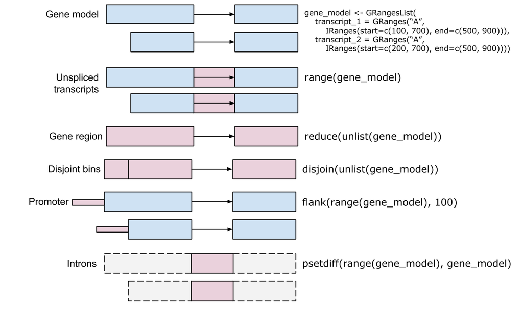

Alt Ranges Algebra

Ranges - IRanges - `start()` / `end()` / `width()` - Vector-like – `length()`, subset, etc. - ‘metadata’, `mcols()` - GRanges - ‘seqnames’ (chromosome), ‘strand’ - `Seqinfo`, including `seqlevels` and `seqlengths`

Intra-range methods - Independent of other ranges in the same object - GRanges variants strand-aware - `shift()`, `narrow()`, `flank()`, `promoters()`, `resize()`, `restrict()`, `trim()` - See `?"intra-range-methods"`

Inter-range methods - Depends on other ranges in the same object - `range()`, `reduce()`, `gaps()`, `disjoin()` - `coverage()` (!) - see `?"inter-range-methods"`

Between-range methods - Functions of two (or more) range objects - `findOverlaps()`, `countOverlaps()`, …, `%over%`, `%within%`, `%outside%`; `union()`, `intersect()`, `setdiff()`, `punion()`, `pintersect()`, `psetdiff()`

IRangesList, GRangesList - List: all elements of the same type - Many *List-aware methods, but a common ‘trick’: apply a vectorized function to the unlisted representaion, then re-list

```
    grl <- GRangesList(...)
    orig_gr <- unlist(grl)
    transformed_gr <- FUN(orig)
    transformed_grl <- relist(transformed_gr, grl)
```

# 3 How to use high-throughput sequence data types in *Bioconductor*

The following sections briefly summarize some of the most important file types in high-throughput sequence analysis. *Briefly* review these, or those that are most relevant to your research, before starting on the section Data Representation in *R* / *Bioconductor*

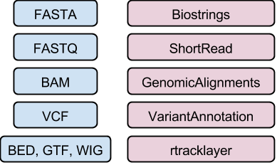

Alt Files and the Bioconductor packages that input them

## 3.1 DNA / amino acid sequences: FASTA files

Input & manipulation: Biostrings

```
>NM_078863_up_2000_chr2L_16764737_f chr2L:16764737-16766736
gttggtggcccaccagtgccaaaatacacaagaagaagaaacagcatctt
gacactaaaatgcaaaaattgctttgcgtcaatgactcaaaacgaaaatg
...
atgggtatcaagttgccccgtataaaaggcaagtttaccggttgcacggt
>NM_001201794_up_2000_chr2L_8382455_f chr2L:8382455-8384454
ttatttatgtaggcgcccgttcccgcagccaaagcactcagaattccggg
cgtgtagcgcaacgaccatctacaaggcaatattttgatcgcttgttagg
...
```

## 3.2 Reads: FASTQ files

Input & manipulation: ShortRead `readFastq()`, `FastqStreamer()`, `FastqSampler()`

```
@ERR127302.1703 HWI-EAS350_0441:1:1:1460:19184#0/1
CCTGAGTGAAGCTGATCTTGATCTACGAAGAGAGATAGATCTTGATCGTCGAGGAGATGCTGACCTTGACCT
+
HHGHHGHHHHHHHHDGG<GDGGE@GDGGD<?B8??ADAD<BE@EE8EGDGA3CB85*,77@>>CE?=896=:
@ERR127302.1704 HWI-EAS350_0441:1:1:1460:16861#0/1
GCGGTATGCTGGAAGGTGCTCGAATGGAGAGCGCCAGCGCCCCGGCGCTGAGCCGCAGCCTCAGGTCCGCCC
+
DE?DD>ED4>EEE>DE8EEEDE8B?EB<@3;BA79?,881B?@73;1?########################
```

- Quality scores: ‘phred-like’, encoded. See [wikipedia](http://en.wikipedia.org/wiki/FASTQ_format#Encoding)

## 3.3 Aligned reads: BAM files (e.g., ERR127306_chr14.bam)

Input & manipulation: ‘low-level’ Rsamtools, `scanBam()`, `BamFile()`; ‘high-level’ GenomicAlignments

- Header

  ```
    @HD     VN:1.0  SO:coordinate
    @SQ     SN:chr1 LN:249250621
    @SQ     SN:chr10        LN:135534747
    @SQ     SN:chr11        LN:135006516
    ...
    @SQ     SN:chrY LN:59373566
    @PG     ID:TopHat       VN:2.0.8b       CL:/home/hpages/tophat-2.0.8b.Linux_x86_64/tophat --mate-inner-dist 150 --solexa-quals --max-multihits 5 --no-discordant --no-mixed --coverage-search --microexon-search --library-type fr-unstranded --num-threads 2 --output-dir tophat2_out/ERR127306 /home/hpa…
  ```

- Alignments: ID, flag, alignment and mate

  ```
    ERR127306.7941162       403     chr14   19653689        3       72M             =       19652348        -1413  ...
    ERR127306.22648137      145     chr14   19653692        1       72M             =       19650044        -3720  ...
    ERR127306.933914        339     chr14   19653707        1       66M120N6M       =       19653686        -213   ...
    ERR127306.11052450      83      chr14   19653707        3       66M120N6M       =       19652348        -1551  ...
    ERR127306.24611331      147     chr14   19653708        1       65M120N7M       =       19653675        -225   ...
    ERR127306.2698854       419     chr14   19653717        0       56M120N16M      =       19653935        290    ...
    ERR127306.2698854       163     chr14   19653717        0       56M120N16M      =       19653935        2019   ...
  ```

- Alignments: sequence and quality

  ```
    ... GAATTGATCAGTCTCATCTGAGAGTAACTTTGTACCCATCACTGATTCCTTCTGAGACTGCCTCCACTTCCC        *'%%%%%#&&%''#'&%%%)&&%%$%%'%%'&*****$))$)'')'%)))&)%%%%$'%%%%&"))'')%))
    ... TTGATCAGTCTCATCTGAGAGTAACTTTGTACCCATCACTGATTCCTTCTGAGACTGCCTCCACTTCCCCAG        '**)****)*'*&*********('&)****&***(**')))())%)))&)))*')&***********)****
    ... TGAGAGTAACTTTGTACCCATCACTGATTCCTTCTGAGACTGCCTCCACTTCCCCAGCAGCCTCTGGTTTCT        '******&%)&)))&")')'')'*((******&)&'')'))$))'')&))$)**&&****************
    ... TGAGAGTAACTTTGTACCCATCACTGATTCCTTCTGAGACTGCCTCCACTTCCCCAGCAGCCTCTGGTTTCT        ##&&(#')$')'%&&#)%$#$%"%###&!%))'%%''%'))&))#)&%((%())))%)%)))%*********
    ... GAGAGTAACTTTGTACCCATCACTGATTCCTTCTGAGACTGCCTCCACTTCCCCAGCAGCCTCTGGTTTCTT        )&$'$'$%!&&%&&#!'%'))%''&%'&))))''$""'%'%&%'#'%'"!'')#&)))))%$)%)&'"')))
    ... TTTGTACCCATCACTGATTCCTTCTGAGACTGCCTCCACTTCCCCAGCAGCCTCTGGTTTCTTCATGTGGCT        ++++++++++++++++++++++++++++++++++++++*++++++**++++**+**''**+*+*'*)))*)#
    ... TTTGTACCCATCACTGATTCCTTCTGAGACTGCCTCCACTTCCCCAGCAGCCTCTGGTTTCTTCATGTGGCT        ++++++++++++++++++++++++++++++++++++++*++++++**++++**+**''**+*+*'*)))*)#
  ```

- Alignments: Tags

  ```
    ... AS:i:0  XN:i:0  XM:i:0  XO:i:0  XG:i:0  NM:i:0  MD:Z:72 YT:Z:UU NH:i:2  CC:Z:chr22      CP:i:16189276   HI:i:0
    ... AS:i:0  XN:i:0  XM:i:0  XO:i:0  XG:i:0  NM:i:0  MD:Z:72 YT:Z:UU NH:i:3  CC:Z:=  CP:i:19921600   HI:i:0
    ... AS:i:0  XN:i:0  XM:i:0  XO:i:0  XG:i:0  NM:i:4  MD:Z:72 YT:Z:UU XS:A:+  NH:i:3  CC:Z:=  CP:i:19921465   HI:i:0
    ... AS:i:0  XN:i:0  XM:i:0  XO:i:0  XG:i:0  NM:i:4  MD:Z:72 YT:Z:UU XS:A:+  NH:i:2  CC:Z:chr22      CP:i:16189138   HI:i:0
    ... AS:i:0  XN:i:0  XM:i:0  XO:i:0  XG:i:0  NM:i:5  MD:Z:72 YT:Z:UU XS:A:+  NH:i:3  CC:Z:=  CP:i:19921464   HI:i:0
    ... AS:i:0  XM:i:0  XO:i:0  XG:i:0  MD:Z:72 NM:i:0  XS:A:+  NH:i:5  CC:Z:=  CP:i:19653717   HI:i:0
    ... AS:i:0  XM:i:0  XO:i:0  XG:i:0  MD:Z:72 NM:i:0  XS:A:+  NH:i:5  CC:Z:=  CP:i:19921455   HI:i:1
  ```

## 3.4 Called variants: VCF files

Input and manipulation: VariantAnnotation `readVcf()`, `readInfo()`, `readGeno()` selectively with `ScanVcfParam()`.

- Header

  ```
      ##fileformat=VCFv4.2
      ##fileDate=20090805
      ##source=myImputationProgramV3.1
      ##reference=file:///seq/references/1000GenomesPilot-NCBI36.fasta
      ##contig=<ID=20,length=62435964,assembly=B36,md5=f126cdf8a6e0c7f379d618ff66beb2da,species="Homo sapiens",taxonomy=x>
      ##phasing=partial
      ##INFO=<ID=DP,Number=1,Type=Integer,Description="Total Depth">
      ##INFO=<ID=AF,Number=A,Type=Float,Description="Allele Frequency">
      ...
      ##FILTER=<ID=q10,Description="Quality below 10">
      ##FILTER=<ID=s50,Description="Less than 50% of samples have data">
      ...
      ##FORMAT=<ID=GT,Number=1,Type=String,Description="Genotype">
      ##FORMAT=<ID=GQ,Number=1,Type=Integer,Description="Genotype Quality">
  ```

- Location

  ```
      #CHROM POS     ID        REF    ALT     QUAL FILTER ...
      20     14370   rs6054257 G      A       29   PASS   ...
      20     17330   .         T      A       3    q10    ...
      20     1110696 rs6040355 A      G,T     67   PASS   ...
      20     1230237 .         T      .       47   PASS   ...
      20     1234567 microsat1 GTC    G,GTCT  50   PASS   ...
  ```

- Variant INFO

  ```
      #CHROM POS     ...    INFO                              ...
      20     14370   ...    NS=3;DP=14;AF=0.5;DB;H2           ...
      20     17330   ...    NS=3;DP=11;AF=0.017               ...
      20     1110696 ...    NS=2;DP=10;AF=0.333,0.667;AA=T;DB ...
      20     1230237 ...    NS=3;DP=13;AA=T                   ...
      20     1234567 ...    NS=3;DP=9;AA=G                    ...
  ```

- Genotype FORMAT and samples

  ```
      ... POS     ...  FORMAT      NA00001        NA00002        NA00003
      ... 14370   ...  GT:GQ:DP:HQ 0|0:48:1:51,51 1|0:48:8:51,51 1/1:43:5:.,.
      ... 17330   ...  GT:GQ:DP:HQ 0|0:49:3:58,50 0|1:3:5:65,3   0/0:41:3
      ... 1110696 ...  GT:GQ:DP:HQ 1|2:21:6:23,27 2|1:2:0:18,2   2/2:35:4
      ... 1230237 ...  GT:GQ:DP:HQ 0|0:54:7:56,60 0|0:48:4:51,51 0/0:61:2
      ... 1234567 ...  GT:GQ:DP    0/1:35:4       0/2:17:2       1/1:40:3
  ```

## 3.5 Genome annotations: BED, WIG, GTF, etc. files

Input: rtracklayer `import()`

- BED: range-based annotation (see http://genome.ucsc.edu/FAQ/FAQformat.html for definition of this and related formats)
- WIG / bigWig: dense, continuous-valued data
- GTF: gene model
  - Component coordinates

    ```
          7   protein_coding  gene        27221129    27224842    .   -   . ...
          ...
          7   protein_coding  transcript  27221134    27224835    .   -   . ...
          7   protein_coding  exon        27224055    27224835    .   -   . ...
          7   protein_coding  CDS         27224055    27224763    .   -   0 ...
          7   protein_coding  start_codon 27224761    27224763    .   -   0 ...
          7   protein_coding  exon        27221134    27222647    .   -   . ...
          7   protein_coding  CDS         27222418    27222647    .   -   2 ...
          7   protein_coding  stop_codon  27222415    27222417    .   -   0 ...
          7   protein_coding  UTR         27224764    27224835    .   -   . ...
          7   protein_coding  UTR         27221134    27222414    .   -   . ...
    ```

  - Annotations

    ```
          gene_id "ENSG00000005073"; gene_name "HOXA11"; gene_source "ensembl_havana"; gene_biotype "protein_coding";
          ...
          ... transcript_id "ENST00000006015"; transcript_name "HOXA11-001"; transcript_source "ensembl_havana"; tag "CCDS"; ccds_id "CCDS5411";
          ... exon_number "1"; exon_id "ENSE00001147062";
          ... exon_number "1"; protein_id "ENSP00000006015";
          ... exon_number "1";
          ... exon_number "2"; exon_id "ENSE00002099557";
          ... exon_number "2"; protein_id "ENSP00000006015";
          ... exon_number "2";
          ...
          ...
    ```

# 4 Exercises: Data representation in *R* / *Bioconductor*

This section briefly illustrates how different high-throughput sequence data types are represented in *R* / *Bioconductor*. Select relevant data types for your area of interest, and work through the examples. Take time to consult help pages, understand the output of function calls, and the relationship between standard data formats (summarized in the previous section) and the corresponding *R* / *Bioconductor* representation.

## 4.1 *Biostrings* (DNA or amino acid sequences)

Classes

- XString, XStringSet, e.g., DNAString (genomes), DNAStringSet (reads)

Methods –

- [Cheat sheat](http://bioconductor.org/packages/release/bioc/vignettes/Biostrings/inst/doc/BiostringsQuickOverview.pdf)
- Manipulation, e.g., `reverseComplement()`
- Summary, e.g., `letterFrequency()`
- Matching, e.g., `matchPDict()`, `matchPWM()`

Related packages

- BSgenome
  - Whole-genome representations
  - Model and custom
- ShortRead
  - FASTQ files

Example

- Whole-genome sequences are distrubuted by ENSEMBL, NCBI, and others as FASTA files; model organism whole genome sequences are packaged into more user-friendly `BSgenome` packages. The following calculates GC content across chr14.

  ```r
  library(BSgenome.Hsapiens.UCSC.hg38)
  chr14_range = GRanges("chr14", IRanges(1, seqlengths(Hsapiens)["chr14"]))
  chr14_dna <- getSeq(Hsapiens, chr14_range)
  letterFrequency(chr14_dna, "GC", as.prob=TRUE)
  ```

  ```
  ##            G|C
  ## [1,] 0.3454924
  ```

**Exercises**

0. Setup
   - Mouse CDS sequence, from Ensembl: https://useast.ensembl.org/info/data/ftp/index.html

   ```r
   library(Biostrings)
   url <- "ftp://ftp.ensembl.org/pub/release-92/fasta/mus_musculus/cds/Mus_musculus.GRCm38.cds.all.fa.gz"
   fl <- BiocFileCache::bfcrpath(rnames = url)
   ```

   ```
   ## adding rname 'ftp://ftp.ensembl.org/pub/release-92/fasta/mus_musculus/cds/Mus_musculus.GRCm38.cds.all.fa.gz'
   ```

   ```r
   cds <- rtracklayer::import(fl, "fasta")
   ```

1. For simplicity, clean up the data to remove cds with width not a multiple of three. Remove cds that don’t start with a start codon `ATG` or end with a stop codon `c("TAA", "TAG", "TGA")`

   ```r
   pred1 <- width(cds) %% 3 == 0
   table(pred1)
   ```

   ```
   ## pred1
   ## FALSE  TRUE
   ##  7219 58251
   ```

   ```r
   pred2 <- narrow(cds, 1, 3) == "ATG"
   stops <- c("TAA", "TAG", "TGA")
   pred3 <- narrow(cds, width(cds) - 2, width(cds)) %in% stops
   table(pred1 & pred2 & pred3)
   ```

   ```
   ##
   ## FALSE  TRUE
   ## 16808 48662
   ```

   ```r
   cds <- cds[ pred1 & pred2 & pred3 ]
   ```

2. What does the distribution of widths of the cds look like? Which cds has maximum width?

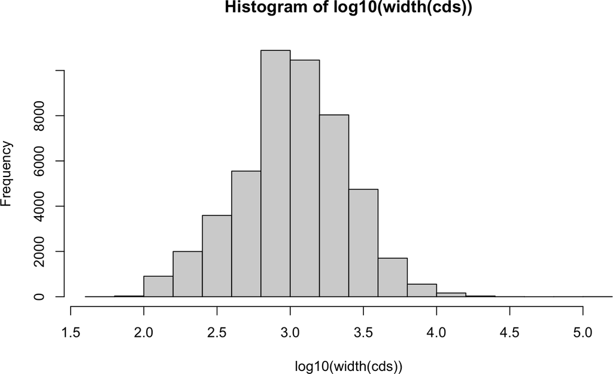

   ```r
   hist(log10(width(cds)))
   ```

   ```r
   cds[ which.max(width(cds)) ]
   ```

   ```
   ## DNAStringSet object of length 1:
   ##      width seq                                              names
   ## [1] 105642 ATGACTACTCAAGCACCGATGTT...TATTAATATCCGTTCTATGTAA ENSMUST0000009998...
   ```

   ```r
   names(cds)[ which.max(width(cds)) ]
   ```

   ```
   ## [1] "ENSMUST00000099981.8 cds chromosome:GRCm38:2:76703980:76982455:-1 gene:ENSMUSG00000051747.14 gene_biotype:protein_coding transcript_biotype:protein_coding gene_symbol:Ttn description:titin [Source:MGI Symbol;Acc:MGI:98864]"
   ```

3. Use `letterFrequency()` to calculate the GC content of each cds; visualize the distribution of GC content.

   ```r
   gc <- letterFrequency(cds, "GC", as.prob=TRUE)
   head(gc)
   ```

   ```
   ##            G|C
   ## [1,] 0.5026624
   ## [2,] 0.5026624
   ## [3,] 0.5026624
   ## [4,] 0.4879075
   ## [5,] 0.5066079
   ## [6,] 0.5714286
   ```

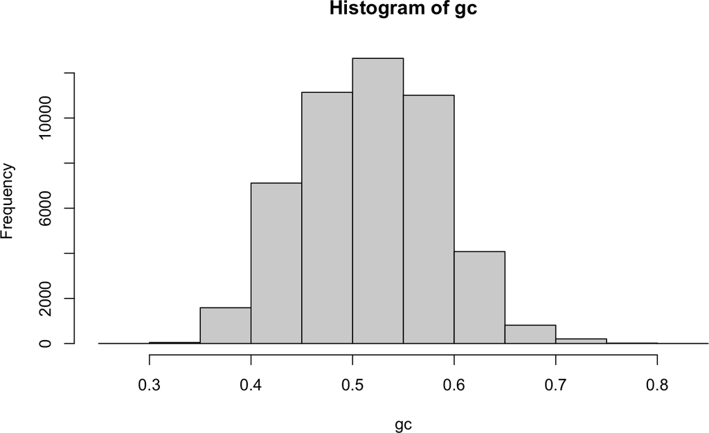

   ```r
   hist(gc)
   ```

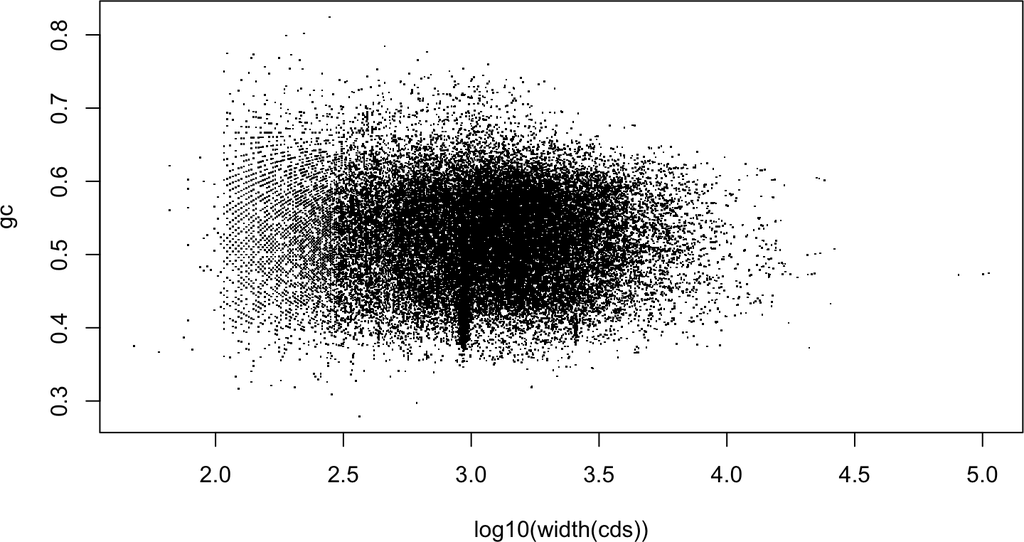

   ```r
   plot( log10(width(cds)), gc, pch=".")
   ```

4. Summarize codon usage in each CDS. Which codons are used most frequently over all CDS?

   ```r
   AMINO_ACID_CODE
   ```

   ```
   ##     A     R     N     D     C     Q     E     G     H     I     L     K     M
   ## "Ala" "Arg" "Asn" "Asp" "Cys" "Gln" "Glu" "Gly" "His" "Ile" "Leu" "Lys" "Met"
   ##     F     P     S     T     W     Y     V     U     O     B     J     Z     X
   ## "Phe" "Pro" "Ser" "Thr" "Trp" "Tyr" "Val" "Sec" "Pyl" "Asx" "Xle" "Glx" "Xaa"
   ```

   ```r
   aa <- translate(cds)
   codon_use <- letterFrequency(aa, names(AMINO_ACID_CODE))
   head(codon_use)
   ```

   ```
   ##       A  R  N  D  C  Q  E  G  H  I  L  K  M  F  P  S  T  W  Y  V U O B J Z X
   ## [1,] 17 12 10  7 11 12 11 14  5 20 47 12  6 23 17 24 19  3 11 30 0 0 0 0 0 0
   ## [2,] 17 12 10  7 11 12 11 14  5 20 47 12  6 23 17 24 19  3 11 30 0 0 0 0 0 0
   ## [3,] 17 12 10  7 11 12 11 14  5 20 47 12  6 23 17 24 19  3 11 30 0 0 0 0 0 0
   ## [4,] 25 11  8  6  5  5  7 11 10 34 40 11 10 20 14 36 26  2 11 23 0 0 0 0 0 0
   ## [5,] 36 25 22 26 15 38 30 40 20 27 63 32 11 24 40 86 59 11 34 40 0 0 0 0 0 0
   ## [6,]  0  0  0  0 14 10  5  0  0  0  2  8  1  1 29  3  1  0  0  2 0 0 0 0 0 0
   ```

5. (Advanced) – `DNAStringSet` inherits from `Vector` and `Annotated`, which means that each element (sequence) can have additional information, for instance we can associate GC content with each sequence

   ```r
   mcols(cds) <- DataFrame(
       GC = gc[,"G|C"]
   )
   mcols(cds, use.names = FALSE)
   ```

   ```
   ## DataFrame with 48662 rows and 1 column
   ##              GC
   ##       <numeric>
   ## 1      0.502662
   ## 2      0.502662
   ## 3      0.502662
   ## 4      0.487907
   ## 5      0.506608
   ## ...         ...
   ## 48658  0.627869
   ## 48659  0.625755
   ## 48660  0.659102
   ## 48661  0.649718
   ## 48662  0.596270
   ```

   ```r
   mcols(cds[1:3], use.names = FALSE)
   ```

   ```
   ## DataFrame with 3 rows and 1 column
   ##          GC
   ##   <numeric>
   ## 1  0.502662
   ## 2  0.502662
   ## 3  0.502662
   ```

## 4.2 *SummarizedExperiment*

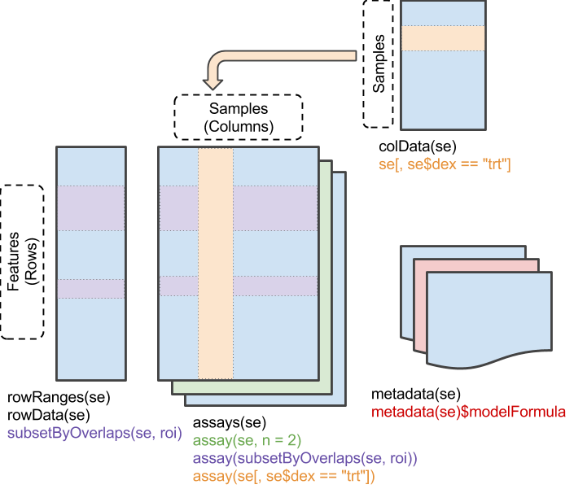

Motivation: reproducible & interoperable

- Matrix of feature x sample measurements, `assays()`
- Addition description about samples, `colData()`
  - Covariates, e.g., age, gender
  - Experimental design, e.g., treatment group
- Additional information about features, `rowData()`
  - Gene names, width, GC content, …
  - Genomic ranges(!)
  - Derived values, E.g., log-fold change between treatments, *P*-value, …
- Information about the experiment as a whole – `metadata()`

Example 1: Bulk RNA-seq `airway` data

- Attach the airway library and data set

  ```r
  library(airway)
  data(airway)
  airway
  ```

  ```
  ## class: RangedSummarizedExperiment
  ## dim: 63677 8
  ## metadata(1): ''
  ## assays(1): counts
  ## rownames(63677): ENSG00000000003 ENSG00000000005 ... ENSG00000273492
  ##   ENSG00000273493
  ## rowData names(10): gene_id gene_name ... seq_coord_system symbol
  ## colnames(8): SRR1039508 SRR1039509 ... SRR1039520 SRR1039521
  ## colData names(9): SampleName cell ... Sample BioSample
  ```

- Explore the phenotypic data describing samples. Subset to include just the `"untrt"` samples.

  ```r
  colData(airway)
  ```

  ```
  ## DataFrame with 8 rows and 9 columns
  ##            SampleName     cell      dex    albut        Run avgLength
  ##              <factor> <factor> <factor> <factor>   <factor> <integer>
  ## SRR1039508 GSM1275862  N61311     untrt    untrt SRR1039508       126
  ## SRR1039509 GSM1275863  N61311     trt      untrt SRR1039509       126
  ## SRR1039512 GSM1275866  N052611    untrt    untrt SRR1039512       126
  ## SRR1039513 GSM1275867  N052611    trt      untrt SRR1039513        87
  ## SRR1039516 GSM1275870  N080611    untrt    untrt SRR1039516       120
  ## SRR1039517 GSM1275871  N080611    trt      untrt SRR1039517       126
  ## SRR1039520 GSM1275874  N061011    untrt    untrt SRR1039520       101
  ## SRR1039521 GSM1275875  N061011    trt      untrt SRR1039521        98
  ##            Experiment    Sample    BioSample
  ##              <factor>  <factor>     <factor>
  ## SRR1039508  SRX384345 SRS508568 SAMN02422669
  ## SRR1039509  SRX384346 SRS508567 SAMN02422675
  ## SRR1039512  SRX384349 SRS508571 SAMN02422678
  ## SRR1039513  SRX384350 SRS508572 SAMN02422670
  ## SRR1039516  SRX384353 SRS508575 SAMN02422682
  ## SRR1039517  SRX384354 SRS508576 SAMN02422673
  ## SRR1039520  SRX384357 SRS508579 SAMN02422683
  ## SRR1039521  SRX384358 SRS508580 SAMN02422677
  ```

  ```r
  airway[ , airway$dex == "untrt"]
  ```

  ```
  ## class: RangedSummarizedExperiment
  ## dim: 63677 4
  ## metadata(1): ''
  ## assays(1): counts
  ## rownames(63677): ENSG00000000003 ENSG00000000005 ... ENSG00000273492
  ##   ENSG00000273493
  ## rowData names(10): gene_id gene_name ... seq_coord_system symbol
  ## colnames(4): SRR1039508 SRR1039512 SRR1039516 SRR1039520
  ## colData names(9): SampleName cell ... Sample BioSample
  ```

- Calculate library size as the column sums of the assays. Reflect on the relationship between library size and cell / dex column variables and consequences for differential expression analysis.

  ```r
  colSums(assay(airway))
  ```

  ```
  ## SRR1039508 SRR1039509 SRR1039512 SRR1039513 SRR1039516 SRR1039517 SRR1039520
  ##   20637971   18809481   25348649   15163415   24448408   30818215   19126151
  ## SRR1039521
  ##   21164133
  ```

Example 2 (advanced): single-cell RNA-seq.

- Retrieve mouse embryo data derived from La Manno A et al., 2016, Molecular diversity of midbrain development in mouse, human, and stem cells; *Cell* 167(2), 566-580.

  ```r
  sce <- scRNAseq::LaMannoBrainData("mouse-embryo")
  ```

**Exercises**

- What is the frequency of 0 counts in the single cell assay data?
- What is the distribution of library sizes in the single cell assay data?
- Create a random sample of 100 cells and visualize the relationship between samples using `dist()` and `cmdscale()`.
- can you identify what column of `colData()` is responsible for any pattern you see?
- In exploring the covariates, are the possible problems with confounding?